# BI624_PS1: SF-Seq Quality Assessment Assignment

Nicki Zavoshy

9/27/2017

- I am working on these two files: 29_4E_fox and 32_4G_both
- loaded easybuild intel/2017a FastQC
- fastqc version : FastQC v0.11.5

### Part 1

1. finding the proper commands for fastqc

`fastqc -o fastqc_out --noextract -f fastq -t 4 29_4E_fox_S21_L008_R1_001.fastq.gz 29_4E_fox_S21_L008_R2_001.fastq.gz 32_4G_both_S23_L008_R1_001.fastq.gz 32_4G_both_S23_L008_R2_001.fastq.gz`

- Plots from FastQC

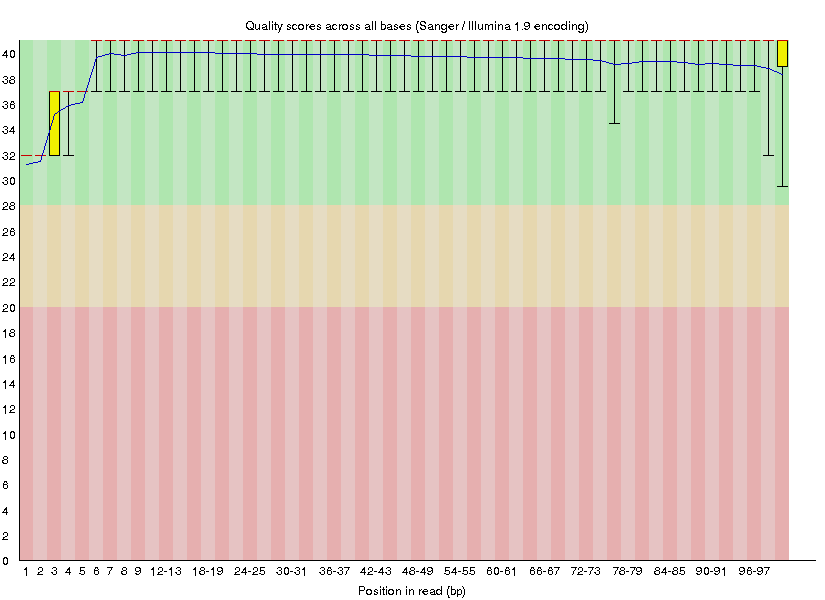

Library 29 Read 1 quality score distributions

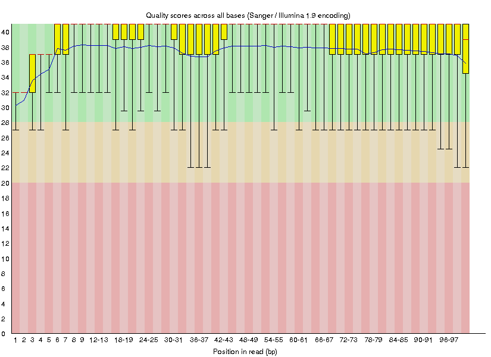

Library 29 Read 2 quality score distributions

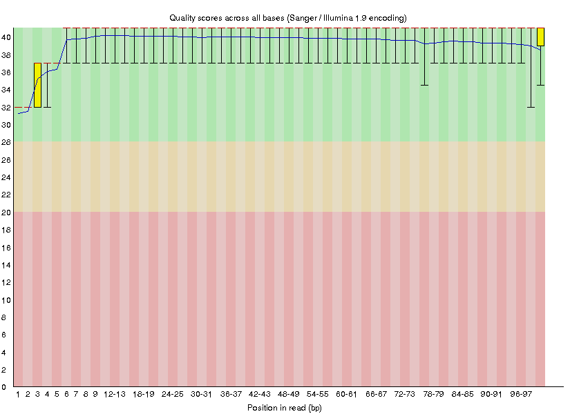

Library 32 Read 1 quality score distributions

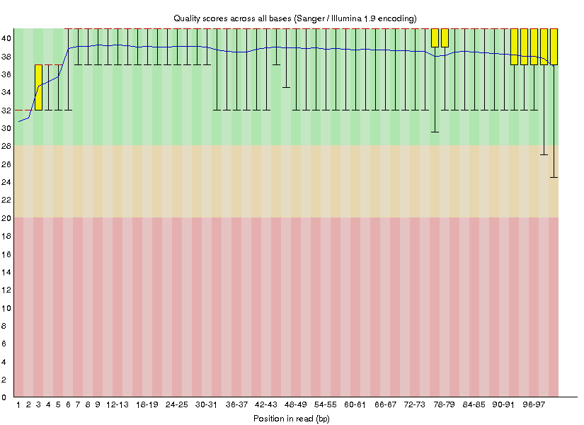

Library 32 Read 2 quality score distributions

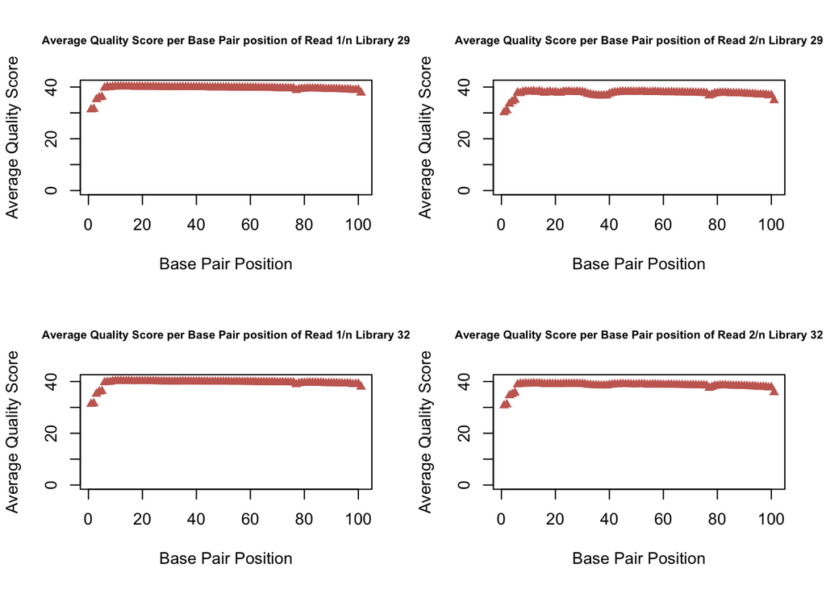

- My plots look pretty much the same as the plots that FastQC generated, which is encouraging that my program did what it was supposed to do. The same dips were reported in my graphs as can be seen in the FASTqc graphs.I think that it woudl be interesting to encourporate the error bar aspect into my graphs to see if those would also follow the same pattern.

### Part 2

3. Comparing the trimming programs and reporting the results
- cutadapt is a program that trims adapters, is N or other wildcard character tolerant, is capable of working on paired end reads, is also error tolerant for things such as indels or undetermined base calls. This program is written in Python 2.
- Trimmomatic is program that also trims adapters and goes through a serious of steps for illumina adapter trimming. Requires a fastafile with adapters in it. It also can do palindrome or simple trimming. It appeared there was more manipulation of the data in order to use trimmomatic than I was willing to put into it when more simple options appeared to be available(such as cutadapt and process_shortreads). This program is written in Java
- process_shortreads is a program that we have used before that has very easy command line options. It allows for paired end processing, and is capable of doing lots of different types of quality filtering if those options are chosen. It is part of stacks.

*Cutadapt command is located in the cutadapt.sh

- How many reads were actually trimmed?

Library 29 `1357283/9654866`

about 14% of the reads were trimmed

Library 32 `762699/23640348` about 3% of the reads were trimmed

- Commands used to determine lengths of the sequences that were trimmed:

`grep -A 1 "@" 29_R1.out.fastq| grep -v '^--'| awk '{print length($0)}' | sort -n | uniq -c > 29_R1_readlen.txt`

`grep -A 1 "@" 29_R2.out.fastq| grep -v '^--'| awk '{print length($0)}' | sort -n | uniq -c > 29_R2_readlen.txt`

`grep -A 1 "@" 32_R1.out.fastq| grep -v '^--'| awk '{print length($0)}' | sort -n | uniq -c > 32_R1_readlen.txt`

`grep -A 1 "@" 32_R2.out.fastq| grep -v '^--'| awk '{print length($0)}' | sort -n | uniq -c > 32_R2_readlen.txt`

4. Plotting read lengths

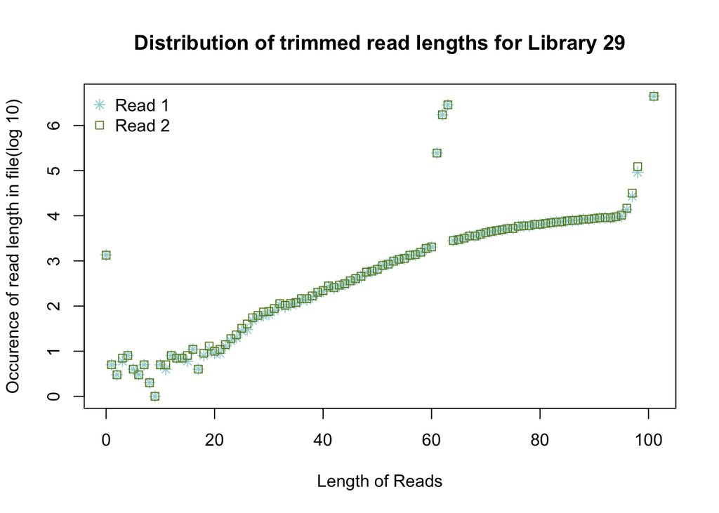

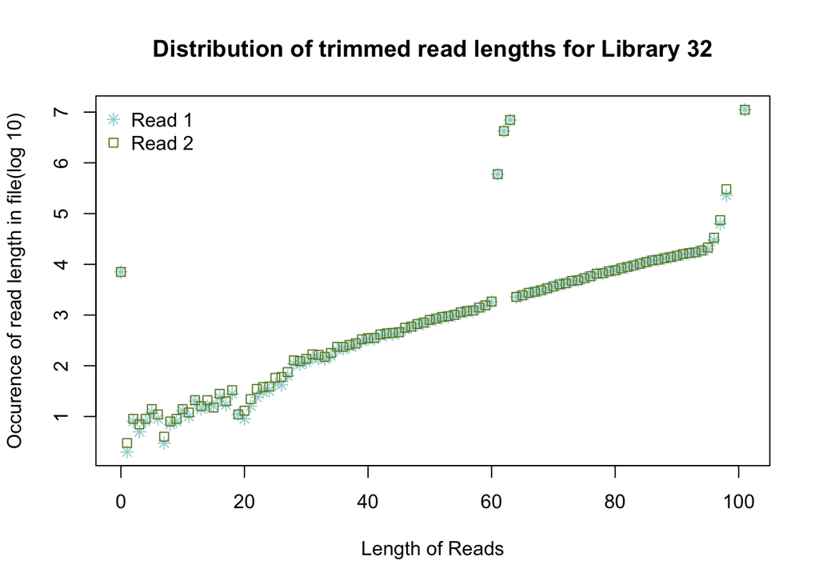

5. The adapter trimming results are consistent for the libraries that I am looking at. For the 29 library, the average insert size was 419 bp and 14% of the reads were trimmed. For library 32, the average insert size was 420 bp and 3% of the read were trimmed. With insert sizes this large, we would expect to have a very low amount of adapter contamination, since the average insert library size is significantly longer than the sequence that the HiSeq is able to sequence. If there was a high level of adapter contamination, then someone likely went wrong with sequencing and the data would need to inspected more closely.

### Part 3 rRNA reads and strandedness

6. rRNA reads were taken from rfam and searched for just Mus musculus hits. These were then fed into a single file, which was used to generate a gsnap database. That script is in `gmap_db.sh`. Alignment to the trimmed library sequences was then executed in the `gsnap.sh` script. For determining the proportion of contamination of rRNA, I decided to do the line count of the reads that did not map to any of the rRNA, calculate that percentage, and then subtract that from 100%. I chose this method because it seemed to have the least room for error, and I would be able to consider that any reads that were not included in this portion, mapped to an rRNA sequence in some capacity(i.e. half mapped).
- Command to determine proportition of contamination in library 29:

`grep -v '@' 29_trimmed.nomapping | wc -l 9153740`

- About 5% of the reads were likely from rRNA, which is relatively good.
- Command to determine proportion of contamination in library 32:

`grep -v '@' 32_trimmed.nomapping | wc -l 23127191`

`grep 'AAAAAAAAAAAAAAAAAAAA$' 29_4E_fox_S21_L008_R1_001.fastq | wc -l 241`

`grep 'AAAAAAAAAAAAAAAAAAAA$' 29_4E_fox_S21_L008_R2_001.fastq | wc -l 1927`

`grep 'TTTTTTTTTTTTTTTTTTTT$' 29_4E_fox_S21_L008_R1_001.fastq | wc -l 2058`

`grep 'TTTTTTTTTTTTTTTTTTTT$' 29_4E_fox_S21_L008_R2_001.fastq | wc -l 415`

- 20 consecutive bases in library 32:

`grep 'AAAAAAAAAAAAAAAAAAAA$' 32_4G_both_S23_L008_R1_001.fastq | wc -l 675`

`grep 'AAAAAAAAAAAAAAAAAAAA$' 32_4G_both_S23_L008_R2_001.fastq | wc -l 3315`

`grep 'TTTTTTTTTTTTTTTTTTTT$' 32_4G_both_S23_L008_R1_001.fastq | wc -l 4879`

`grep 'TTTTTTTTTTTTTTTTTTTT$' 32_4G_both_S23_L008_R2_001.fastq | wc -l 1391`

Graphical representation of proportions of reads:

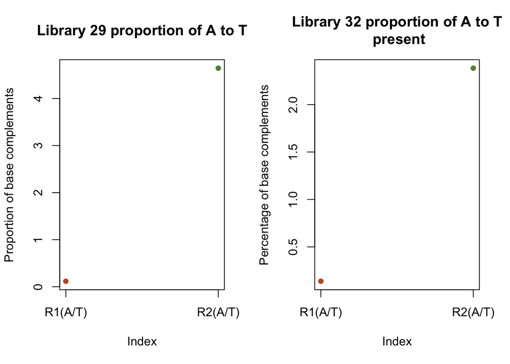

Numeric representation of the proportions of reads:

Library 29

|  | Proportion | Count of polyAs | Count of polyTs |
| --- | --- | --- | --- |
| R1 | 0.117104 | 241 | 2058 |
| R2 | 4.643374 | 1927 | 415 |

Library 32

|  | Proportion | Count of polyAs | Count of polyTs |
| --- | --- | --- | --- |
| R1 | 0.138348 | 675 | 4879 |
| R2 | 2.383178 | 3315 | 1391 |

- As we can see in both the table and the graphical representation, these libraries are stranded. The evidence for this is that there is a higher proportion of A’s in one read, signifiying the polyA tail of the mRNA we are looking at, and a higher proportion of T’s in the reverse read. If these values were equal in both read 1 and read 2, then they would likely not be stranded due to equal sequencing of both the desired and the complementary strand.